# Assignment #1

### ETS Laboratory

#### (40 points)

#### Due: Nov. 6 (before 9:00am)

In this assignment we will focus on longer term forecast as it is appropriate for aggregate planning and/or facilities planning.

We are interested in obtaining a 5 year forecast (60 months to be precise) of the size of the grocery store market in the US, and we want that forecast in monthly (not weekly) intervals. Such a forecast is useful if you are preparing an infrastructure plan for a grocery store chain for example: this type of forecast is useful to make decisions about number of new stores to open, number of distribution centers and their capacity, personnel and other infrastructure decisions.

The data set “**MRTSSM4451USN.csv**” includes monthly retail sales of grocery stores in the US from January 1992 through December 2017 expressed in millions of US dollars.  
Source: https://fred.stlouisfed.org/series/MRTSSM4451USN

The first thing we need to do is load the data file and convert it into an appropriate time-series object. This is accomplished with the following code:

```r
library(fpp2)
library(dplyr)
#
# Read csv file and make it a time series
GS <- read.csv("MRTSSM4451USN.csv") %>%
  select(-DATE) %>%
  ts(start= c(1992,1), frequency=12)
```

In this assignment we will learn to use the **ets(…)** function to fit and analyze exponential smoothing models. Before proceeding to fit a model we examine and divide the data into two sets; a training set **tr** that we will use to fit the models and a testing (or hold-out) data set **te** to assess the out-of-sample performance of the models. This is accomplished with the following code:

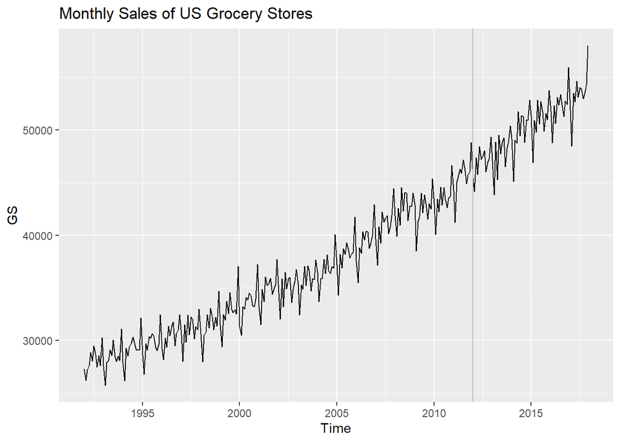

```r
## Training set
tr <- window(GS, end=c(2011,12))
## Testing Set
te <- window(GS, start=c(2012,1))

autoplot(GS) +
  geom_vline(xintercept=2012.0, color="gray") +
  ggtitle("Monthly Sales of US Grocery Stores")
```

```
Based on your analysis above, discuss the forecast bias and compare the in-sample and out-of-sample *MASE*.  What do you think is driving the poor model performance?  Which model/method, **f.HW** or **naive**,  would you choose for forecasting?
```

```r
### Fitting the ets function with additive errors (ANN)

f.hw <- ets(tr, model = "AZZ", damped = NULL)
## Printing the summary
print(" following is the summary of the Holt Winters Model which includes values of constants, smoothing parameters and AIC, AICc and BIC along with in-sample fitting indicators")
```

```
## [1] " following is the summary of the Holt Winters Model which includes values of constants, smoothing parameters and AIC, AICc and BIC along with in-sample fitting indicators"
```

```r
print(summary(f.hw))
```

```
## ETS(A,Ad,A)
##
## Call:
##  ets(y = tr, model = "AZZ", damped = NULL)
##
##   Smoothing parameters:
##     alpha = 0.1459
##     beta  = 0.1458
##     gamma = 1e-04
##     phi   = 0.8296
##
##   Initial states:
##     l = 27975.7976
##     b = 56.6232
##     s = 2422.541 -171.9733 -150.2665 -813.5405 576.5694 1151.272
##            23.4452 1149.711 -759.5466 33.5565 -2880.456 -581.3123
##
##   sigma:  539.2869
##
##      AIC     AICc      BIC
## 4353.040 4356.135 4415.692
##
## Training set error measures:
##                    ME     RMSE      MAE       MPE     MAPE      MASE
## Training set 88.18648 519.8364 408.3749 0.2297179 1.164242 0.4025102
##                    ACF1
## Training set -0.2909248
##                    ME     RMSE      MAE       MPE     MAPE      MASE
## Training set 88.18648 519.8364 408.3749 0.2297179 1.164242 0.4025102
##                    ACF1
## Training set -0.2909248
```

```r
cat("The AIC Value is", f.hw$aic)
```

```
## The AIC Value is 4353.04
```

```r
cat("the BIC value is", f.hw$bic)
```

```
## the BIC value is 4415.692
```

```r
cat(" the AICc value is",f.hw$aicc )
```

```
##  the AICc value is 4356.135
```

```r
## Question 2

## Forecasting for the 72 months
print(" Following is the plot of forecast with actual")
```

```
## [1] " Following is the plot of forecast with actual"
```

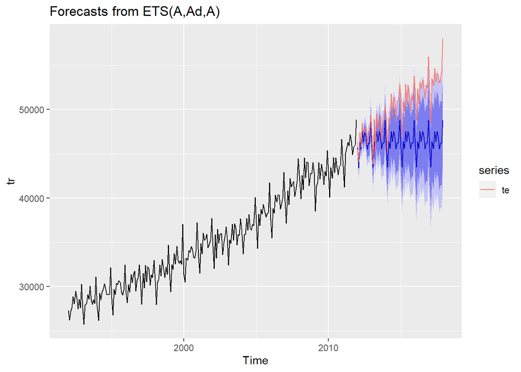

```r
fc.hw <- forecast(f.hw, h = 72)
autoplot(fc.hw)+
autolayer(te)
```

```r
## Question3

## Creating the zoomed in function

print("following is the zoomed in plot of the forecast")
```

```
## [1] "following is the zoomed in plot of the forecast"
```

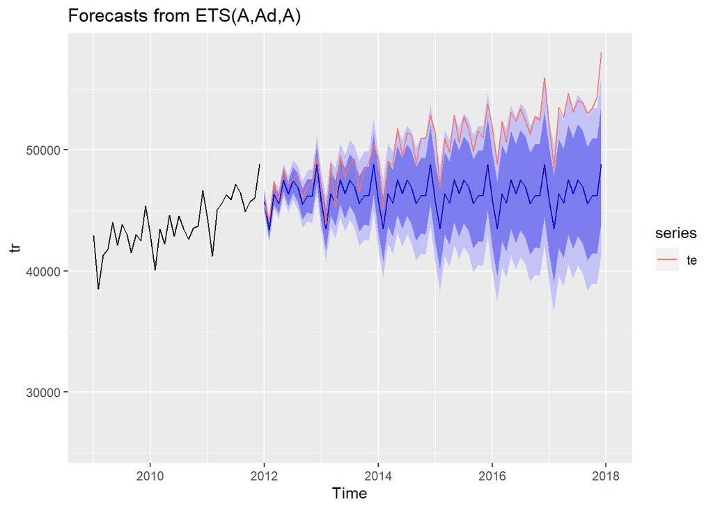

```r
autoplot(fc.hw)+
autolayer(te)+
  xlim(2009,2018)
```

```r
## Question 4


print("Following are the in-sample and out-of-sample statistics")
```

```
## [1] "Following are the in-sample and out-of-sample statistics"
```

```r
print(accuracy(fc.hw,te))
```

```
##                      ME      RMSE       MAE       MPE     MAPE      MASE
## Training set   88.18648  519.8364  408.3749 0.2297179 1.164242 0.4025102
## Test set     3914.49248 4589.1061 3928.8918 7.5627144 7.594424 3.8724692
##                    ACF1 Theil's U
## Training set -0.2909248        NA
## Test set      0.8546705  1.854899
```

The Above analysis was carried out by using a smoothing model with additive errors. Upon looking at the plot of the time series, it appears that it has a positive trend and monthly seasonality. However, The trend component was not incorporated in our model as it is damped in our model. This is because of forcing additive error model on the data. This resulted in a relatively detrend forecast for next 72 months, where as the actuals trend increased progressively

It is due to the same above mentioned reason that, by looking at individual in-sample metrics, the errors values are coming up to be high, which are further getting increased when calculating on out of sample (show in out-of-sample metrics)

By looking at teh out of sample MASE, since it is greater than 1, it can be said that the model is performing worse than the Naive model on test dataset. Thus we can choose Niave model over this model

2. (5 pts.) Holt-Winters Model Analysis: part II:
- Optimize the parameters of a Holt-Winters model disallowing damping of growth (i.e., use the **damped = FALSE** directive in the call to the **ets(…)** function). Call the fitted model **f.HW2**, and report the model details including the optimized value of each of the constants and smoothing parameters required by the model, the *AIC, AICc* and *BIC* values, as well as the in-sample fitting indicators.
- Obtain a 72-month-ahead forecast, name this forecast **fc.HW2** and plot it.
- Calculate the *in-sample* and *out-of-sample* fit statistics of the **fc.HW2** forecast.
- As in Question (1), compare the out-of-sample metrics of **fc.HW** and **fc.HW2**. Discuss also the confidence interval cone of both models, and their implications for operations planning.

```r
### Fitting the ets function with additive errors (ANN)

f.hw2 <- ets(tr, model = "AZZ", damped = FALSE)
## Printing the summary
print(" following is the value of each constant and smoothing parameter of the Holt Winters Model ")
```

```
## [1] " following is the value of each constant and smoothing parameter of the Holt Winters Model "
```

```r
print((f.hw2$par))
```

```
##         alpha          beta         gamma             l             b
##  2.634885e-01  5.077510e-03  1.000157e-04  2.797412e+04  5.188094e+01
##            s0            s1            s2            s3            s4
##  2.427198e+03 -1.789884e+02 -1.449864e+02 -8.263089e+02  5.836564e+02
##            s5            s6            s7            s8            s9
##  1.151710e+03  1.934974e+01  1.150373e+03 -7.579677e+02  3.016971e+01
##           s10
## -2.865102e+03
```

```r
cat("The AIC Value is", f.hw2$aic)
```

```
## The AIC Value is 4355.353
```

```r
cat("the BIC value is", f.hw2$bic)
```

```
## the BIC value is 4414.524
```

```r
cat(" the AICc value is",f.hw2$aicc )
```

```
##  the AICc value is 4358.109
```

```r
print("Following is the summary with in-sample fitting indicators")
```

```
## [1] "Following is the summary with in-sample fitting indicators"
```

```r
print(summary(f.hw2))
```

```
## ETS(A,A,A)
##
## Call:
##  ets(y = tr, model = "AZZ", damped = FALSE)
##
##   Smoothing parameters:
##     alpha = 0.2635
##     beta  = 0.0051
##     gamma = 1e-04
##
##   Initial states:
##     l = 27974.1193
##     b = 51.8809
##     s = 2427.198 -178.9884 -144.9864 -826.3089 583.6564 1151.71
##            19.3497 1150.373 -757.9677 30.1697 -2865.102 -589.1037
##
##   sigma:  542.938
##
##      AIC     AICc      BIC
## 4355.353 4358.109 4414.524
##
## Training set error measures:
##                    ME    RMSE      MAE        MPE     MAPE      MASE
## Training set 41.56951 524.528 406.0665 0.09009096 1.159924 0.4002351
##                    ACF1
## Training set -0.2788064
##                    ME    RMSE      MAE        MPE     MAPE      MASE
## Training set 41.56951 524.528 406.0665 0.09009096 1.159924 0.4002351
##                    ACF1
## Training set -0.2788064
```

```r
## Question 2

## Forecasting for the 72 months
print(" Following is the plot of forecast with actual")
```

```
## [1] " Following is the plot of forecast with actual"
```

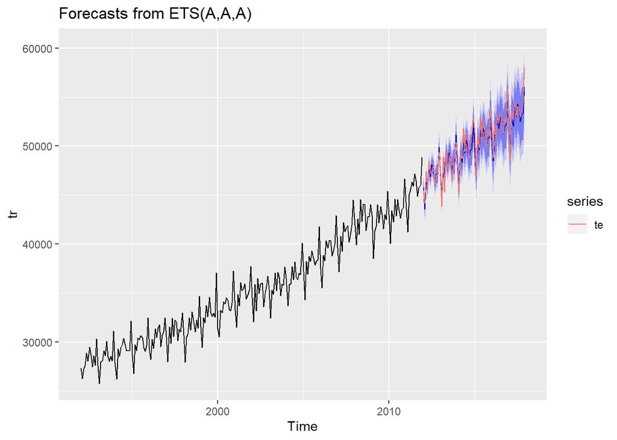

```r
fc.hw2 <- forecast(f.hw2, h = 72)
autoplot(fc.hw2)+
autolayer(te)
```

```r
## Creating the zoomed in function

print("following is the zoomed in plot of the forecast")
```

```
## [1] "following is the zoomed in plot of the forecast"
```

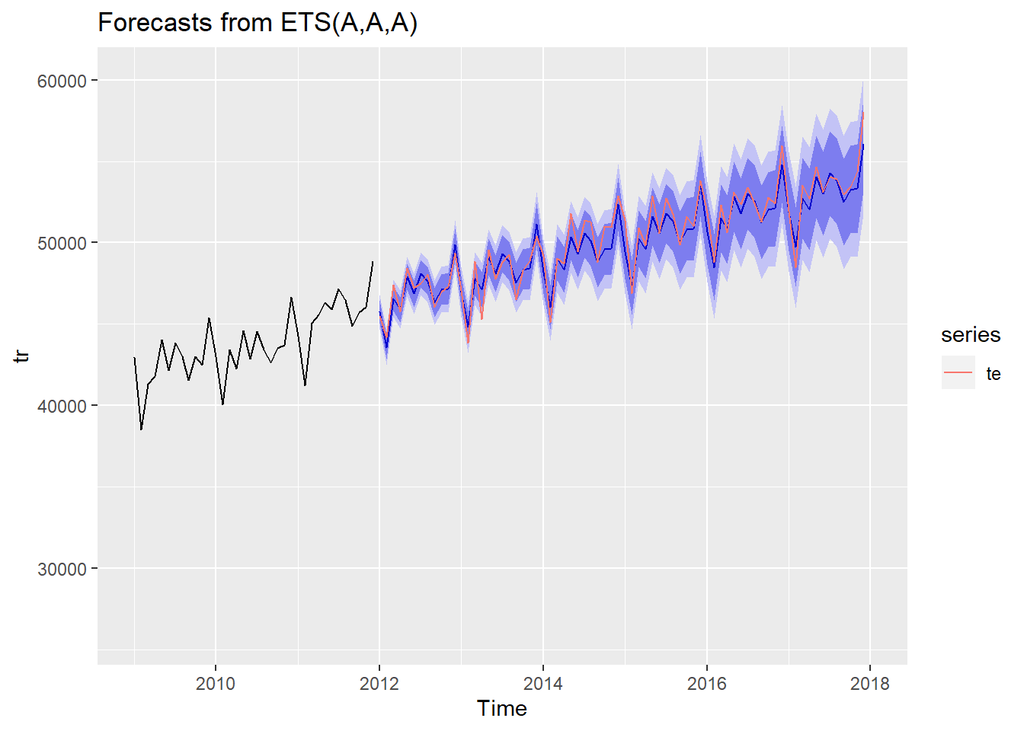

```r
autoplot(fc.hw2)+
autolayer(te)+
  xlim(2009,2018)
```

```r
##Computing the in-sample and outof sample

print("following is the in-sample and out-of-sample metrics")
```

```
## [1] "following is the in-sample and out-of-sample metrics"
```

```r
print(accuracy(fc.hw2,te))
```

```
##                     ME     RMSE      MAE        MPE     MAPE      MASE
## Training set  41.56951 524.5280 406.0665 0.09009096 1.159924 0.4002351
## Test set     291.54776 757.7241 591.5288 0.53593606 1.173839 0.5830339
##                     ACF1 Theil's U
## Training set -0.27880638        NA
## Test set     -0.09174218 0.3159545
```

```r
acctableint <- accuracy(fc.hw2,te)
acctablef <- (acctableint[c("Test set"),])
acctableint2 <- accuracy(fc.hw,te)
acctablef <- rbind(acctablef,acctableint2[c("Test set"),])
row.names(acctablef) <- c("fc.hw2","fc.hw")
print("following is the out of sample metric comparisions between the forecast from question 2 and 1")
```

```
## [1] "following is the out of sample metric comparisions between the forecast from question 2 and 1"
```

```r
print(acctablef)
```

```
##               ME      RMSE       MAE       MPE     MAPE      MASE
## fc.hw2  291.5478  757.7241  591.5288 0.5359361 1.173839 0.5830339
## fc.hw  3914.4925 4589.1061 3928.8918 7.5627144 7.594424 3.8724692
##               ACF1 Theil's U
## fc.hw2 -0.09174218 0.3159545
## fc.hw   0.85467045 1.8548989
```

We can see there is a huge difference between the evaluation metrics. It is because the optimized model is incorporating the trend of the time series while forecasting.

The confidence interval cones of both models expands as the forecasted year value increases. If going by the previous model in operations, the amount of storage inventory will increase linearly as the months will pass by because the confidence cone widens as forecasted months increase. This increase in uncertainity will add to increase in cost and add also the risk because the confidence cone has an equivalent negitive demand as well If going by this model (fc.hw2) the demand is varying proportional with the confidence interval, so the storage inventory will also vary accordingly, sometimes increasing and decreasing. This can lead to flexible storage based on demand with varying cost

However, in both cases, as the number of months increases, the range of values increases, thus adding to uncertainity. Due to this, it is better to forecast again at specific periods so that the confidence range is within desirable limits

3. (5 pts) Optimal ETS Model Selection: 2
- Now we call the **ets(…)** function using the **model=”ZZZ”** directive to optimize the model selection including multiplicative models (i.e., set the **restrict=FALSE** option). Call the fitted model **f.O**, and report the model details, the *AIC, AICc* and *BIC* values, as well as the in-sample fitting indicators.
- Obtain a 72-month-ahead forecast, name this forecast **fc.O** and plot it.
- Calculate the *in-sample* and *out-of-sample* fit statistics of the **fc.O** forecast.
- Compare the out-of-sample accuracy metrics of **fc.HW**, **fc.HW2** and **fc.O**. Compare the *AIC AICc* and *BIC* of models **f.HW**, **f.HW2** and **f.O**. Which model/method would you choose for forecasting?

```r
### Fitting the ets function with additive errors (ANN)

f.0 <- ets(tr, model = "ZZZ", restrict  = FALSE)
## Printing the summary
print(" following is the summary of the Holt Winters Model ")
```

```
## [1] " following is the summary of the Holt Winters Model "
```

```r
print(summary(f.0))
```

```
## ETS(M,A,A)
##
## Call:
##  ets(y = tr, model = "ZZZ", restrict = FALSE)
##
##   Smoothing parameters:
##     alpha = 0.2328
##     beta  = 0.0041
##     gamma = 1e-04
##
##   Initial states:
##     l = 27978.8076
##     b = 56.015
##     s = 2378.258 -169.2943 -144.1528 -796.7364 575.0091 1156.585
##            38.1926 1153.63 -757.9354 35.1323 -2768.678 -700.0095
##
##   sigma:  0.0154
##
##      AIC     AICc      BIC
## 4352.540 4355.297 4411.711
##
## Training set error measures:
##                    ME     RMSE      MAE        MPE    MAPE      MASE
## Training set 45.28612 529.6129 407.5492 0.09263676 1.15639 0.4016964
##                    ACF1
## Training set -0.2314272
##                    ME     RMSE      MAE        MPE    MAPE      MASE
## Training set 45.28612 529.6129 407.5492 0.09263676 1.15639 0.4016964
##                    ACF1
## Training set -0.2314272
```

```r
cat("The AIC Value is", f.0$aic)
```

```
## The AIC Value is 4352.54
```

```r
cat("the BIC value is", f.0$bic)
```

```
## the BIC value is 4411.711
```

```r
cat(" the AICc value is",f.0$aicc )
```

```
##  the AICc value is 4355.297
```

```r
## Forecasting for the 72 months
print(" Following is the plot of forecast with actual")
```

```
## [1] " Following is the plot of forecast with actual"
```

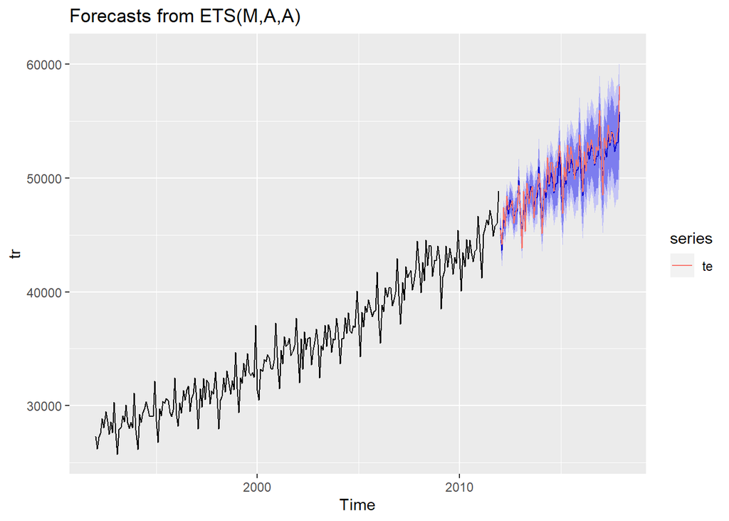

```r
fc.0 <- forecast(f.0, h = 72)
autoplot(fc.0)+
autolayer(te)
```

```r
## Creating the zoomed in function

print("following is the zoomed in plot of the forecast")
```

```
## [1] "following is the zoomed in plot of the forecast"
```

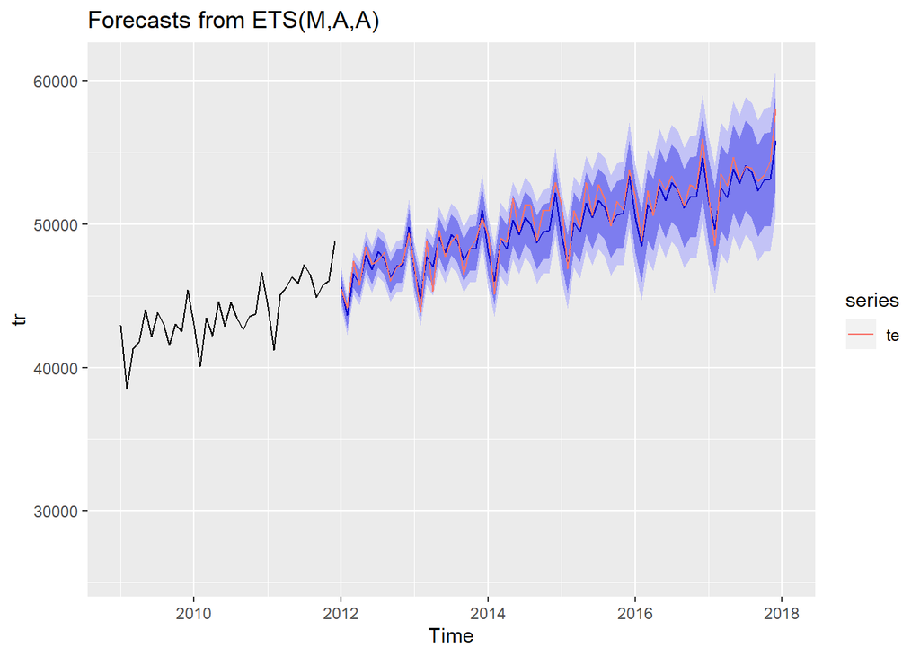

```r
autoplot(fc.0)+
autolayer(te)+
  xlim(2009,2018)
```

```r
print("following is the in-sample and out of sample statistics")
```

```
## [1] "following is the in-sample and out of sample statistics"
```

```r
accuracy(fc.0,te)
```

```
##                     ME     RMSE      MAE        MPE     MAPE      MASE
## Training set  45.28612 529.6129 407.5492 0.09263676 1.156390 0.4016964
## Test set     409.13236 836.6561 666.9141 0.76421242 1.316576 0.6573366
##                     ACF1 Theil's U
## Training set -0.23142723        NA
## Test set     -0.07587836 0.3474461
```

```r
acctableint2 <- accuracy(fc.0,te)
acctablef <- rbind(acctablef,acctableint2[c("Test set"),])
row.names(acctablef) <- c("fc.hw2","fc.hw","fc.0")

print("following is the comparison of the values")
```

```
## [1] "following is the comparison of the values"
```

```r
print(acctablef)
```

```
##               ME      RMSE       MAE       MPE     MAPE      MASE
## fc.hw2  291.5478  757.7241  591.5288 0.5359361 1.173839 0.5830339
## fc.hw  3914.4925 4589.1061 3928.8918 7.5627144 7.594424 3.8724692
## fc.0    409.1324  836.6561  666.9141 0.7642124 1.316576 0.6573366
##               ACF1 Theil's U
## fc.hw2 -0.09174218 0.3159545
## fc.hw   0.85467045 1.8548989
## fc.0   -0.07587836 0.3474461
```

```r
insamtable <- c(f.0$aic,f.0$bic,f.0$aicc)
insamtable<- rbind(insamtable, c(f.hw2$aic,f.hw2$bic, f.hw2$aicc))
insamtable <- rbind(insamtable, c(f.hw$aic,f.hw$bic,f.hw$aicc))

insamtable <- as.data.frame(insamtable)
colnames(insamtable) <- c("AIC","BIC","AICc")
rownames(insamtable) <- c("f.0","f.hw2","f.hw")
print("Following are the AICC BIN and AICc Values")
```

```
## [1] "Following are the AICC BIN and AICc Values"
```

```r
print(insamtable)
```

```
##            AIC      BIC     AICc
## f.0   4352.540 4411.711 4355.297
## f.hw2 4355.353 4414.524 4358.109
## f.hw  4353.040 4415.692 4356.135
```

Based on the comparison of out of sample metrics, we can choose fc.hw2 as the errors are low in comparison, thus producing better results

4. (5 pts) Optimized model using BoxCox-Transformed Data:
- Select the best value of the “*lambda*” parameter for the BoxCox transformation over the training set **tr**, and then use the **ets(…)** function to optimize the model selection as you did in Question (3). Call the fitted model **fB.O**, and report the model details, the *AIC, AICc* and *BIC* values, as well as the in-sample fitting indicators.
- Obtain a 72-month-ahead forecast, name this forecast **fBc.O** and plot it.
- Calculate the in-sample and out-of-sample fit statistics of the **fBc.O** forecast.
- Compare the in-sample and out-of-sample accuracy metrics of **fBc.O** and **fc.O**. Which model/method would you choose for forecasting? Why?

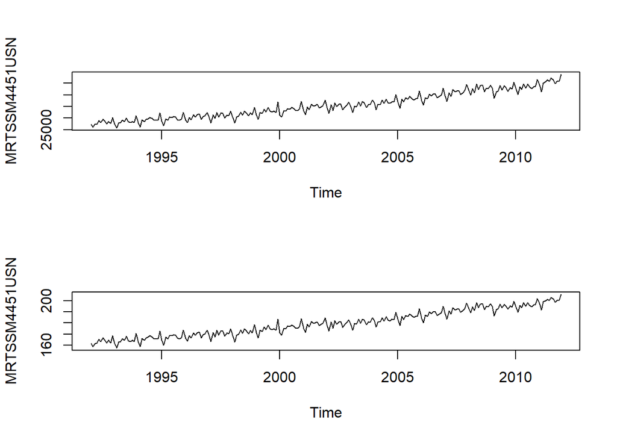

```r
### Fitting the ets function with additive errors (ANN)

L <- BoxCox.lambda(tr)
z <- BoxCox(tr,L)
par(mfrow=c(2,1))
plot(tr)
plot(z)
```

```r
par(mfrow=c(1,1))

print("following is the best value of Lambda")
```

```
## [1] "following is the best value of Lambda"
```

```r
print(L)
```

```
## [1] 0.4124547
```

```r
fB.O <- ets(tr, model = "ZZZ", restrict = F , lambda = L)
## Printing the summary
print(" following is the summary of the Holt Winters Model ")
```

```
## [1] " following is the summary of the Holt Winters Model "
```

```r
print(summary(fB.O))
```

```
## ETS(M,A,A)
##
## Call:
##  ets(y = tr, model = "ZZZ", lambda = L, restrict = F)
##
##   Box-Cox transformation: lambda= 0.4125
##
##   Smoothing parameters:
##     alpha = 0.2389
##     beta  = 0.0025
##     gamma = 1e-04
##
##   Initial states:
##     l = 162.7329
##     b = 0.129
##     s = 5.2015 -0.3899 -0.324 -1.642 1.2789 2.4914
##            0.1262 2.3842 -1.5531 -7e-04 -6.3331 -1.2395
##
##   sigma:  0.0063
##
##      AIC     AICc      BIC
## 1388.401 1391.158 1447.572
##
## Training set error measures:
##                    ME     RMSE      MAE        MPE     MAPE      MASE
## Training set 41.79434 517.1069 396.1544 0.08768066 1.125411 0.3904652
##                    ACF1
## Training set -0.2464292
##                    ME     RMSE      MAE        MPE     MAPE      MASE
## Training set 41.79434 517.1069 396.1544 0.08768066 1.125411 0.3904652
##                    ACF1
## Training set -0.2464292
```

```r
cat("The AIC Value is", fB.O$aic)
```

```
## The AIC Value is 1388.401
```

```r
cat("the BIC value is", fB.O$bic)
```

```
## the BIC value is 1447.572
```

```r
cat(" the AICc value is",fB.O$aicc )
```

```
##  the AICc value is 1391.158
```

```r
## Question 2

## Forecasting for the 72 months
print(" Following is the plot of forecast with actual")
```

```
## [1] " Following is the plot of forecast with actual"
```

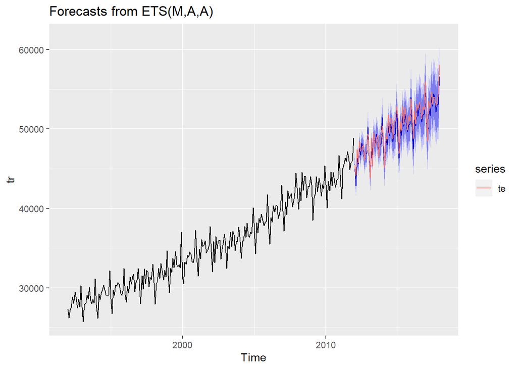

```r
fBc.O <- forecast(fB.O, h = 72)
autoplot(fBc.O)+
autolayer(te)
```

```r
## Creating the zoomed in function

print("following is the zoomed in plot of the forecast")
```

```
## [1] "following is the zoomed in plot of the forecast"
```

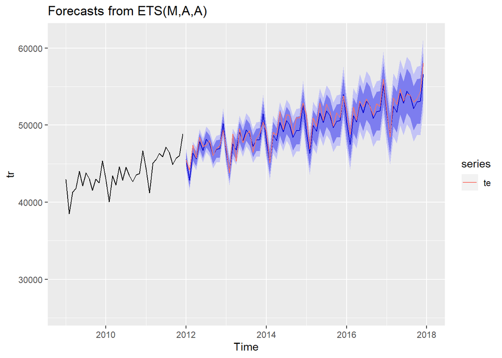

```r
autoplot(fBc.O)+
autolayer(te)+
  xlim(2009,2018)
```

```r
print("Following is the in-sample and out of sample statistics of fBc.0")
```

```
## [1] "Following is the in-sample and out of sample statistics of fBc.0"
```

```r
print(accuracy(fBc.O,te))
```

```
##                     ME     RMSE      MAE        MPE     MAPE      MASE
## Training set  41.79434 517.1069 396.1544 0.08768066 1.125411 0.3904652
## Test set     493.71650 839.8616 681.9229 0.95817270 1.349351 0.6721299
##                     ACF1 Theil's U
## Training set -0.24642919        NA
## Test set     -0.02047443 0.3519391
```

```r
#binding the accuracy in the table
acctableint2 <- accuracy(fBc.O,te)
acctablef <- rbind(acctablef,acctableint2[c("Test set"),])
row.names(acctablef) <- c("fc.hw2","fc.hw","fc.0","fBc.O")
print("following is the comparison of the values")
```

```
## [1] "following is the comparison of the values"
```

```r
print(acctablef[which(rownames(acctablef)== c("fc.0","fBc.O")),])
```

```
##             ME     RMSE      MAE       MPE     MAPE      MASE        ACF1
## fc.0  409.1324 836.6561 666.9141 0.7642124 1.316576 0.6573366 -0.07587836
## fBc.O 493.7165 839.8616 681.9229 0.9581727 1.349351 0.6721299 -0.02047443
##       Theil's U
## fc.0  0.3474461
## fBc.O 0.3519391
```

5. (5 pts) Optimized model with damping using BoxCox-Transformed Data:
- Using the best value of “*lambda*” (i.e., the same you used in Question (4)), and set **damped=TRUE** in the **ets(…)** function. Name the fitted model **fB.OD** and report the model details and metrics.
- Now use the **forecast(…)** function to obtain a 72-month-ahead forecast, name this forecast **fBc.OD** and plot it.
- Use the function **accuracy(…)** to calculate the in-sample and out-of-sample fit statistics of the **fBc.OD** forecast.
- Compare the in-sample and out-of-sample accuracy metrics of **fBc.OD**, **fBc.O** and **fc.O**. Which model/method would you choose for forecasting? Why?

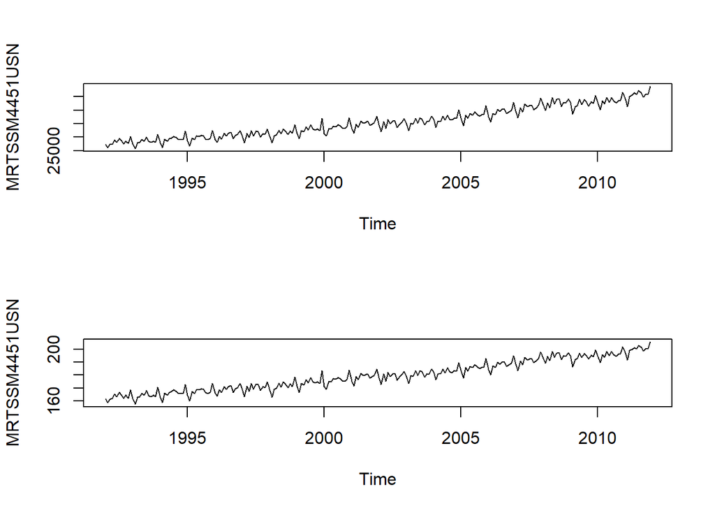

```r
### Fitting the ets function with additive errors (ANN)

L <- BoxCox.lambda(tr)
z <- BoxCox(tr,L)
par(mfrow=c(2,1))
plot(tr)
plot(z)
```

```r
par(mfrow=c(1,1))

print("following is the value of lambda")
```

```
## [1] "following is the value of lambda"
```

```r
print(L)
```

```
## [1] 0.4124547
```

```r
fB.OD <- ets(tr, model = "ZZZ", lambda = L, damped = TRUE)
## Printing the summary
print(" following is the summary of the Holt Winters Model ")
```

```
## [1] " following is the summary of the Holt Winters Model "
```

```r
print(summary(fB.OD))
```

```
## ETS(A,Ad,A)
##
## Call:
##  ets(y = tr, model = "ZZZ", damped = TRUE, lambda = L)
##
##   Box-Cox transformation: lambda= 0.4125
##
##   Smoothing parameters:
##     alpha = 0.24
##     beta  = 0.037
##     gamma = 2e-04
##     phi   = 0.9738
##
##   Initial states:
##     l = 162.9567
##     b = 0.1167
##     s = 5.1097 -0.3524 -0.2634 -1.6545 1.2688 2.525
##            0.0693 2.3392 -1.5837 0.0223 -6.2029 -1.2774
##
##   sigma:  1.1395
##
##      AIC     AICc      BIC
## 1396.391 1399.486 1459.042
##
## Training set error measures:
##                    ME     RMSE      MAE       MPE     MAPE      MASE
## Training set 54.90041 521.5143 404.3219 0.1323105 1.148476 0.3985155
##                    ACF1
## Training set -0.2651727
##                    ME     RMSE      MAE       MPE     MAPE      MASE
## Training set 54.90041 521.5143 404.3219 0.1323105 1.148476 0.3985155
##                    ACF1
## Training set -0.2651727
```

```r
cat("The AIC Value is", fB.OD$aic)
```

```
## The AIC Value is 1396.391
```

```r
cat("the BIC value is", fB.OD$bic)
```

```
## the BIC value is 1459.042
```

```r
cat(" the AICc value is",fB.OD$aicc )
```

```
##  the AICc value is 1399.486
```

```r
## Question 2

## Forecasting for the 72 months
print(" Following is the plot of forecast with actual")
```

```
## [1] " Following is the plot of forecast with actual"
```

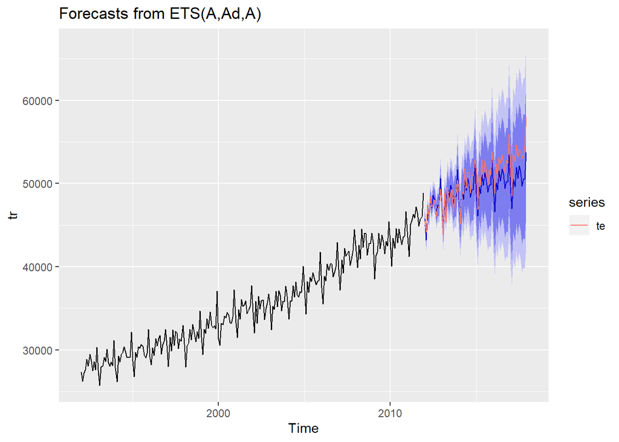

```r
fBc.OD <- forecast(fB.OD, h = 72)
autoplot(fBc.OD)+
autolayer(te)
```

```r
## Creating the zoomed in function

print("following is the zoomed in plot of the forecast")
```

```
## [1] "following is the zoomed in plot of the forecast"
```

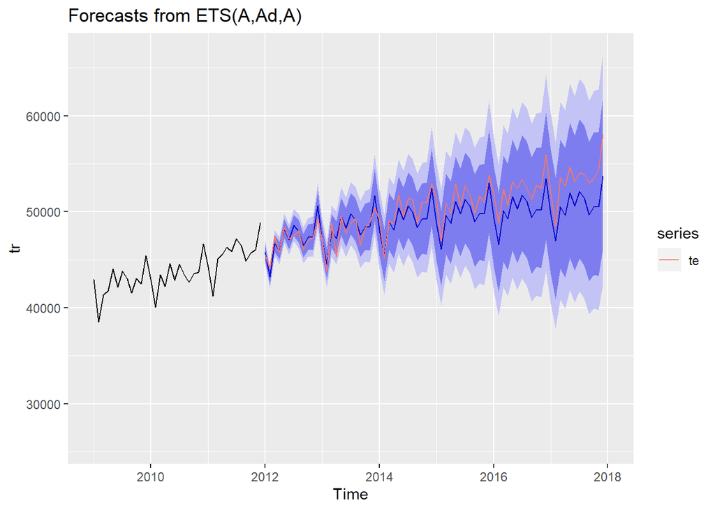

```r
autoplot(fBc.OD)+
autolayer(te)+
  xlim(2009,2018)
```

```r
print("following is the in sample and out of sample statistic for FBc.OD")
```

```
## [1] "following is the in sample and out of sample statistic for FBc.OD"
```

```r
print(accuracy(fBc.OD,te))
```

```
##                      ME      RMSE       MAE       MPE     MAPE      MASE
## Training set   54.90041  521.5143  404.3219 0.1323105 1.148476 0.3985155
## Test set     1063.54803 1676.0717 1355.1376 2.0058627 2.623766 1.3356766
##                    ACF1 Theil's U
## Training set -0.2651727        NA
## Test set      0.6726879 0.6755667
```

```r
#binding the accuracy in the table
acctableint2 <- accuracy(fBc.OD,te)
acctablef <- rbind(acctablef,acctableint2[c("Test set"),])
row.names(acctablef) <- c("fc.hw2","fc.hw","fc.0","fBc.O","fBc.OD")
print(acctablef)
```

```
##               ME      RMSE       MAE       MPE     MAPE      MASE
## fc.hw2  291.5478  757.7241  591.5288 0.5359361 1.173839 0.5830339
## fc.hw  3914.4925 4589.1061 3928.8918 7.5627144 7.594424 3.8724692
## fc.0    409.1324  836.6561  666.9141 0.7642124 1.316576 0.6573366
## fBc.O   493.7165  839.8616  681.9229 0.9581727 1.349351 0.6721299
## fBc.OD 1063.5480 1676.0717 1355.1376 2.0058627 2.623766 1.3356766
##               ACF1 Theil's U
## fc.hw2 -0.09174218 0.3159545
## fc.hw   0.85467045 1.8548989
## fc.0   -0.07587836 0.3474461
## fBc.O  -0.02047443 0.3519391
## fBc.OD  0.67268791 0.6755667
```

```r
print("following is the comparison of the values")
```

```
## [1] "following is the comparison of the values"
```

```r
print(acctablef)
```

```
##               ME      RMSE       MAE       MPE     MAPE      MASE
## fc.hw2  291.5478  757.7241  591.5288 0.5359361 1.173839 0.5830339
## fc.hw  3914.4925 4589.1061 3928.8918 7.5627144 7.594424 3.8724692
## fc.0    409.1324  836.6561  666.9141 0.7642124 1.316576 0.6573366
## fBc.O   493.7165  839.8616  681.9229 0.9581727 1.349351 0.6721299
## fBc.OD 1063.5480 1676.0717 1355.1376 2.0058627 2.623766 1.3356766
##               ACF1 Theil's U
## fc.hw2 -0.09174218 0.3159545
## fc.hw   0.85467045 1.8548989
## fc.0   -0.07587836 0.3474461
## fBc.O  -0.02047443 0.3519391
## fBc.OD  0.67268791 0.6755667
```

Comparing the three models i.e. fBc.OD, fBc.O and fc.O, Based on the values, we can still go with fc.O since the out of sample metrics are low as compared to other models. Thus, it can perform better as compared to rest of the models

6. (5 pts) In an effort to improve forecasts, in this question we want to assess the value of old information and discard the oldest segment of the information that does not have predictive value. To this end code and execute the following: (50th)

Evaluate the selection of a moving training set starting from 1992, 1993, etc all the way to starting in 2006, but in each case keep the end of the training set fixed at December of 2011. For each starting year:

- Select the value of the Box “lambda” for each training set
- Obtain an optimized model using all the **ets**-options that you consider pertinent based on your analysis in previous questions.
- Extract the in-sample *RMSE*
- Based on *RMSE*, select the best starting year for the training set
- Report the lowest *RMSE* and the starting year the generates it
- Create a “reduced” training set starting the year you identified above, and terminating in December of 2011. Name this reduced training set **trr**.
- Explain why we cannot use the *AIC, AICc* or *BIC* criteria to select the best starting year for the training data set.

```r
## Making the dataframe for forecast
library(zoo)
library(zoo)
library(ggplot2)
library(reshape2)
df <- data.frame(date=yearmon(index(tr)), Y = melt(tr)$value)
df$year <- as.Date(df$date, format = "%y")
df$year2 <- format(as.Date(df$year, format="%m/%d/%Y"),"%Y")

### Fitting the ets function with additive errors (ANN)
lmbda_arry <- data.frame()

for(i in 1992:2006){
  #print(i)
  dftemp <- df[which(df$year2>=i),]
  dftemp2 <- dftemp$Y
  trtemp <- ts(dftemp2,start= c(i,1), frequency=12)
  L <- BoxCox.lambda(trtemp)
  z <- BoxCox(trtemp,L)

  fl.0 <- ets(trtemp, model = "ZZZ", restrict  = FALSE)
  flc.O <- forecast(fl.0, h = 72)
  acctr1 <- (accuracy(flc.O,te))

  flB.O <- ets(trtemp, model = "ZZZ", restrict  = FALSE, lambda = L)
  flcb.O <- forecast(flB.O, h = 72)
  acctr2 <- (accuracy(flcb.O,te))

  flB.OD <- ets(trtemp, model = "ZZZ", restrict  = FALSE, lambda = L, damped = TRUE)
  flcB.OD <- forecast(flB.OD, h = 72)
  acctr4 <- accuracy(flcB.OD,te)

  lmbda_arry <- rbind(lmbda_arry,c(L,i,acctr1[3],acctr2[3],acctr4[3]))
}

colnames(lmbda_arry) <- c("L","year","RMSEfc.O","RMSEfBc.O ","RMSEfBc.OD")
lmbda_arry$RMSE_avg <- (lmbda_arry$RMSEfc.O + lmbda_arry$`RMSEfBc.O ` + lmbda_arry$RMSEfBc.OD)/3

print("following is the combination chosen")
```

```
## [1] "following is the combination chosen"
```

```r
print(lmbda_arry[which(lmbda_arry$RMSE_avg == min(lmbda_arry$RMSE_avg)),])
```

```
##            L year RMSEfc.O RMSEfBc.O  RMSEfBc.OD RMSE_avg
## 12 0.5078479 2003 497.3188   494.2976   503.8915 498.5026
```

```r
L <- lmbda_arry[which(lmbda_arry$RMSE_avg == min(lmbda_arry$RMSE_avg)),][1]$L
yearfil <- lmbda_arry[which(lmbda_arry$RMSE_avg == min(lmbda_arry$RMSE_avg)),]$year

## Filtering the year row
dftemp <- df[which(df$year2>=yearfil),]
trr <- dftemp$Y
trtemp <- ts(trr,start= c(yearfil,1), frequency=12)
trr <- trtemp
print("following is the time series data trr")
```

```
## [1] "following is the time series data trr"
```

```r
print(trr)
```

```
##        Jan   Feb   Mar   Apr   May   Jun   Jul   Aug   Sep   Oct   Nov
## 2003 35384 32440 35265 34854 37057 35212 37108 36644 34697 35870 35786
## 2004 36475 33701 35892 35876 37733 36362 38170 36607 36360 37004 36876
## 2005 37176 34286 38210 36908 38742 38219 39289 38627 37844 38251 38354
## 2006 37489 35506 38827 38269 40341 39569 40357 40340 38766 39322 39989
## 2007 39649 37150 40815 39244 42207 41279 41619 41896 40191 40924 41910
## 2008 41864 39915 42590 40966 44549 42299 44057 44010 41378 42811 42751
## 2009 42942 38522 41312 41781 44034 42147 43839 42995 41538 43020 42508
## 2010 42985 40061 43434 42236 44607 42877 44559 43431 42642 43536 43724
## 2011 44282 41229 45068 45586 46318 45883 47171 46448 44877 45725 46046
##        Dec
## 2003 37670
## 2004 40080
## 2005 41761
## 2006 42924
## 2007 44476
## 2008 44032
## 2009 45395
## 2010 46658
## 2011 48843
```

We cannot choose the AIC , BIC and AICc values as they are scaled values of the inner model. Also, since the data window will be changing the AIC, BIC values will keep on improving as they are inversely proportional to the amount of the data. Thus, selecting the model based on these criterias will not give us the desired resutls

7. (5 pts) Fitting a model on the reduced training dataset:
- Figure out the best value of the BoxCox “*lambda*” value for the reduced training data set **trr**, and fit the best *ETS* model to this data. Report the model parameters and metrics. Name this model **f**.
- Obtain a 72-month-ahead forecast, name this forecast **fc** and plot it.
- Calculate the *in-sample* and *out-of-sample* fit statistics of the **fc** forecast.
- Is the in-sample *AICc* for model **f.O** comparable with the in-sample *AICc* for model **f**? Explain.
- Is the in-sample *MASE* for model **f.O** comparable with the in-sample *MASE* for model **f**? Explain.
- Is the *out-of-sample RMSE* for forecast **fc.O** comparable with the *out-of-sample RMSE* for forecast **fc**? Explain. Is the **fc** forecast truly an *out-of-sample* forecast? Explain.

```r
print("Following is the best value of Lambda from the reduced training dataset")
```

```
## [1] "Following is the best value of Lambda from the reduced training dataset"
```

```r
print(L)
```

```
## [1] 0.5078479
```

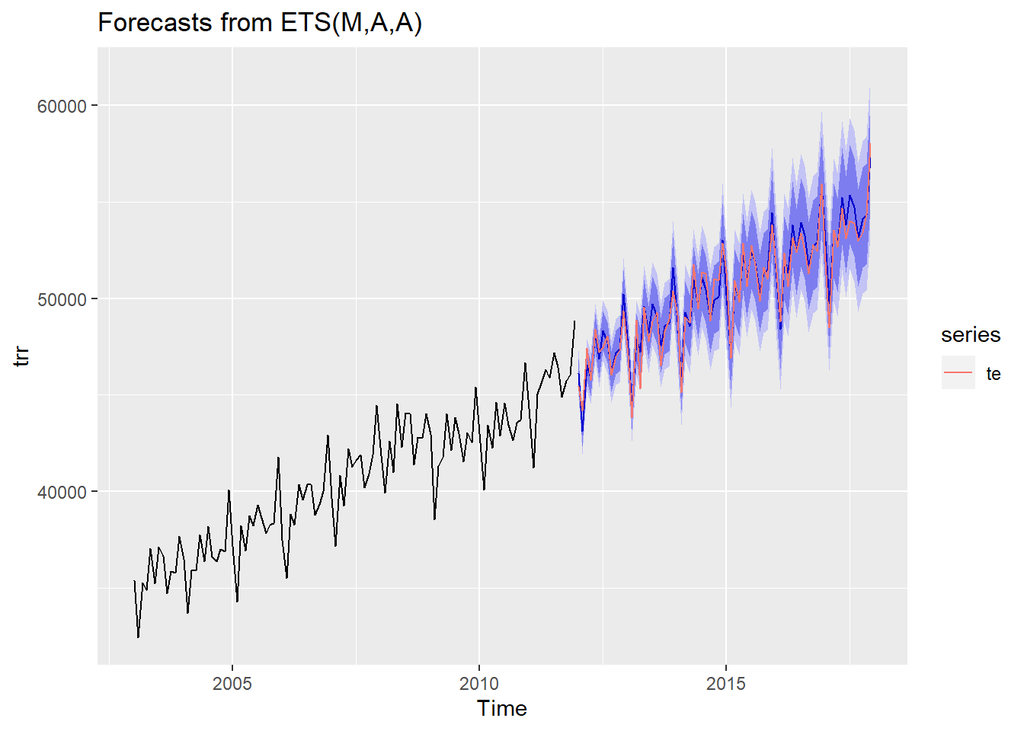

```r
f <- ets(trr, model = "ZZZ", restrict = FALSE, lambda = L)
#flc.O <- forecast(fl.0, h = 72)


## Forecasting for the 72 months
fc <- forecast(f, h = 72)
autoplot(fc)+
autolayer(te)
```

```r
## Creating the zoomed in function
print("following is the zoomed in plot of the forecast")
```

```
## [1] "following is the zoomed in plot of the forecast"
```

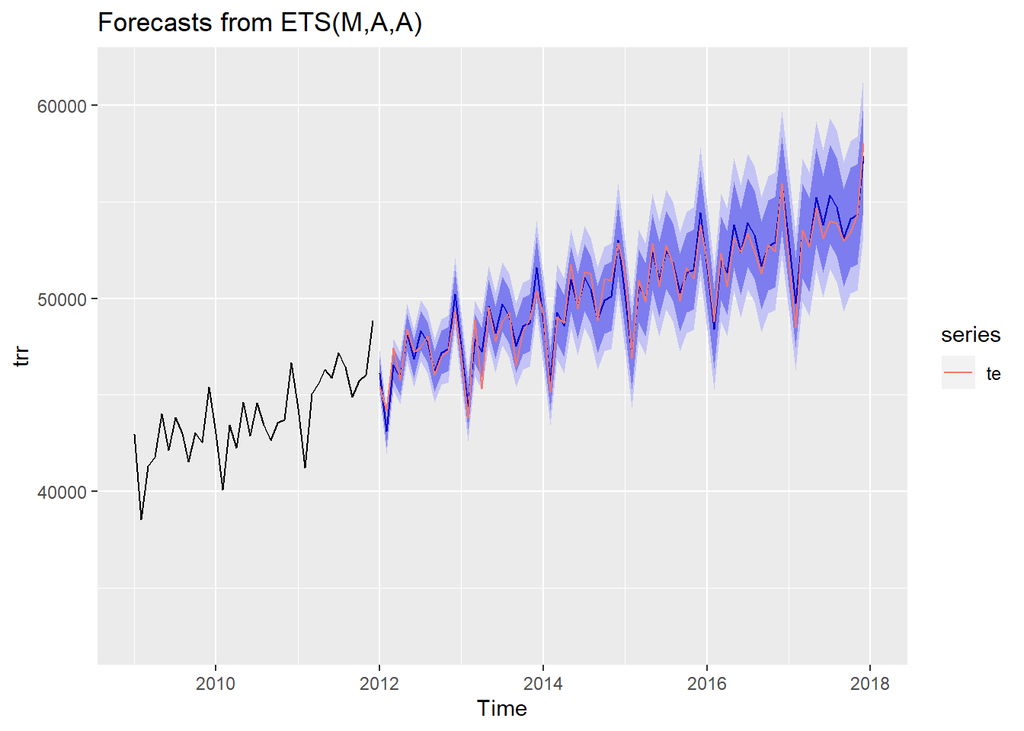

```r
autoplot(fc)+
autolayer(te)+
  xlim(2009,2018)
```

```r
print(" following are the required metrics")
```

```
## [1] " following are the required metrics"
```

```r
print(accuracy(fc,te))
```

```
##                       ME     RMSE      MAE         MPE     MAPE      MASE
## Training set   -5.651558 494.2976 371.9078 -0.02931331 0.919973 0.2744728
## Test set     -145.187830 637.3400 503.6923 -0.29517044 1.010351 0.3717315
##                     ACF1 Theil's U
## Training set -0.16494376        NA
## Test set      0.03156856 0.2657902
```

```r
insamtable <- cbind(f$aic,f$bic,f$aicc)


insamtable <- as.data.frame(insamtable)
colnames(insamtable) <- c("AIC","BIC","AICc")
rownames(insamtable) <- c("f")
print("Following are the AICC BIN and AICc Values")
```

```
## [1] "Following are the AICC BIN and AICc Values"
```

```r
print(insamtable)
```

```
##        AIC      BIC     AICc
## f 749.4563 795.0526 756.2563
```

The AICc is not comparable with the f.0. This is the box-cox transformation forecast, which first standardizes the data and then computes the AICc. Thus the value opbtained is on the scaled data which is different from the one calculated on the raw data by f.O. Thus, they both are not computed with the same data and cannot be compared

The MASE is computed on the model output and because of this, the MASE is comparable between f.o and f, as they both are computed on the same data and can be compared to the naive model

Due to the same reasons, the out of sample RMSE can also be compared. The fc forecast is not truly the out of sample forecast because the optimum value of lambda is chosen by using in-sample RMSE metric on different data windows.

8. (5 pts.) Aggregate Sales Forecast for 2018—2022:
- Next we need to prepare a monthly sales forecast through December 2022. To this end we first set the training set to include all the data starting from the year we selected in Question (6) through December 2017. Select the *ETS* model you analyzed in Question (7), and fit the best parameters to that model. Name the resulting model **ff**.
- Compare the in-sample accuracy of fit statistics of **ff** with those of model **f**.
- Obtain a 60-month-ahead forecast, name this forecast **ffc** and plot it (this time do not include the xlim limits on the forecast plot.
- Based on your analysis what would you expect the out-of-sample (i.e., the actual) *MAPE* be over the next five years? Why?
- You must plan for the expansion of capacity of your system. An important input in this process is the national-wide aggregate grocery store sales. What is the level of nationwide sales that will not be exceeded with a probability of 90%

```r
data8 <- append(trr,te)
tr8 <- ts(data8,start= c(yearfil,1), frequency=12)
print("following is the resulting training dataset")
```

```
## [1] "following is the resulting training dataset"
```

```r
print(tr8)
```

```
##        Jan   Feb   Mar   Apr   May   Jun   Jul   Aug   Sep   Oct   Nov
## 2003 35384 32440 35265 34854 37057 35212 37108 36644 34697 35870 35786
## 2004 36475 33701 35892 35876 37733 36362 38170 36607 36360 37004 36876
## 2005 37176 34286 38210 36908 38742 38219 39289 38627 37844 38251 38354
## 2006 37489 35506 38827 38269 40341 39569 40357 40340 38766 39322 39989
## 2007 39649 37150 40815 39244 42207 41279 41619 41896 40191 40924 41910
## 2008 41864 39915 42590 40966 44549 42299 44057 44010 41378 42811 42751
## 2009 42942 38522 41312 41781 44034 42147 43839 42995 41538 43020 42508
## 2010 42985 40061 43434 42236 44607 42877 44559 43431 42642 43536 43724
## 2011 44282 41229 45068 45586 46318 45883 47171 46448 44877 45725 46046
## 2012 45462 44174 47408 45754 48420 47217 47473 48047 46046 46975 47310
## 2013 47076 43830 48862 45308 49542 47759 48781 49287 46503 48291 48917
## 2014 49165 45122 49034 48727 51777 49459 51374 51298 48826 50994 50945
## 2015 51371 46897 50922 49816 52876 50603 52731 51738 49871 51610 50997
## 2016 51824 48804 52336 50627 53132 52381 53385 52414 51268 52769 52431
```

[output cut: 17 more lines]

```r
ff <- ets(tr8, model = "ZZZ", restrict = F,  lambda = L)

insamtable2 <- cbind(ff$aic,ff$bic,ff$aicc)
colnames(insamtable2) <- c("AIC","BIC","AICc")
insamtable <- rbind(insamtable, insamtable2)
rownames(insamtable) <- c("f","ff")
print("Following are the AICC BIN and AICc Values of model f and ff")
```

```
## [1] "Following are the AICC BIN and AICc Values of model f and ff"
```

```r
print(insamtable)
```

```
##          AIC       BIC      AICc
## f   749.4563  795.0526  756.2563
## ff 1336.7370 1391.0173 1340.5148
```

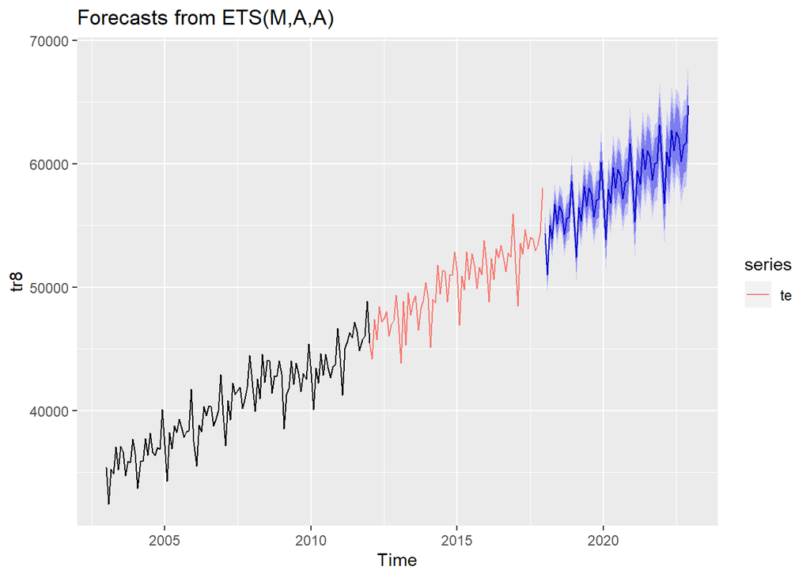

```r
## Forecasting for the 72 months
ffc <- forecast(ff, h = 60)
autoplot(ffc)+
autolayer(te)
```

```r
## Creating the zoomed in function
print("following is the zoomed in plot of the forecast")
```

```
## [1] "following is the zoomed in plot of the forecast"
```

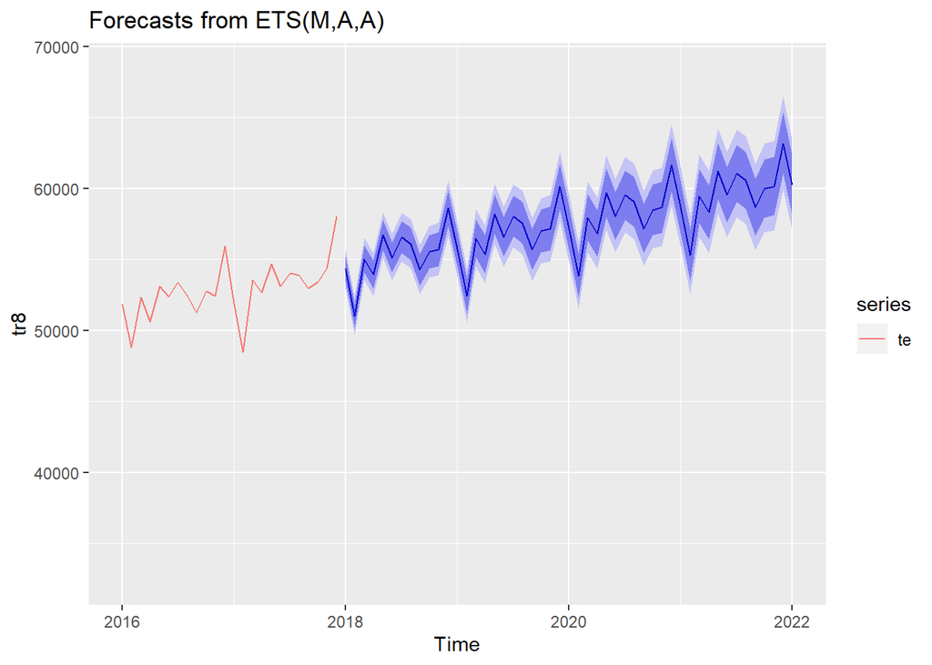

```r
autoplot(ffc)+
autolayer(te)+
  xlim(2016,2022)
```

Following is the forecast of upcoming 60 months with 90% confidence interval

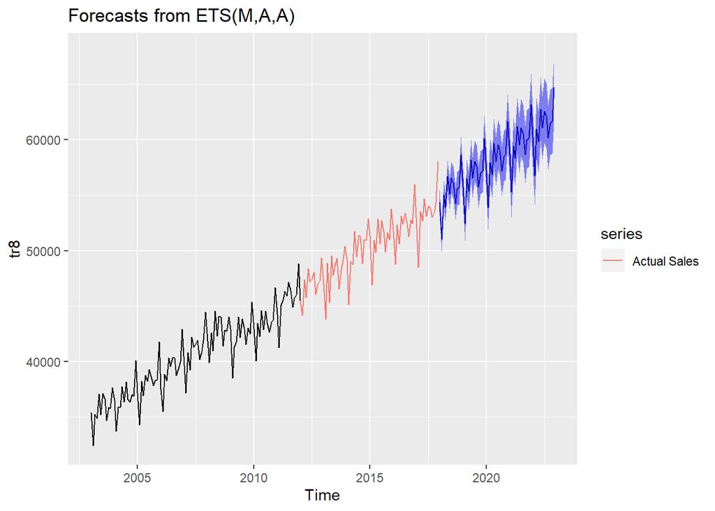

```r
ffc90 = forecast(ff,h=60, level=c(90))

autoplot(ffc90) +
  autolayer(te,series="Actual Sales")
```

Based on the graph above we can say that the Nationwide sales won’t exceed 68000